# Machine Learning - the basics in R

Jan-Philipp Kolb

13 Januar, 2020

# Content of this section

- The first section is about laying the foundations in R. We will need all things covered later on.

### Topics section:

- Why R is a good choice
- Constraints of R-usage
- R is modular
- Import and export of data

# Why R is a good choice …

- … because it is an [**open source language**](https://stackoverflow.com/questions/1546583/what-is-the-definition-of-an-open-source-programming-language)
- … outstanding graphs - [**graphics**](http://matthewlincoln.net/2014/12/20/adjacency-matrix-plots-with-r-and-ggplot2.html), [**graphics**](https://www.r-bloggers.com/3d-plots-with-ggplot2-and-plotly%20/), [**graphics**](https://procomun.wordpress.com/2011/03/18/splomr/)
- … relates to other languages - [**R can be used in combination with other programs**](https://github.com/Japhilko/RInterfaces) - e.g. [**data linking**](https://github.com/Japhilko/RInterfaces/blob/master/slides/Datenimport.md)
- …R can be used [**for automation**](https://cran.r-project.org/web/packages/MplusAutomation/index.html)
- … Vast Community - [**you can use the intelligence of other people ;-)**](https://www.r-bloggers.com/) and new statistical methodologies are implemented quite fast
- Because R can be combined with other programs like `PostgreSQL` or `Python`

# Constraints

### [Newer modules in Python](https://blog.dominodatalab.com/video-huge-debate-r-vs-python-data-science/)

- Machine learning is a field that changes rapidly.
- Some new tools are first developed in Python.
- The package `reticulate` offers the possibility to use these modules from an R environment.
- Good news - Python is also Open Source

### Big Data

- Especially if you work with web data, you quickly have to deal with large amounts of data.
- Therefore one must fall back on databases and parallelization strategies, which can be used in R.

# R is modular

### Install packages from CRAN Server

```r
install.packages("lme4")
```

### Install packages from Bioconductor Server

```r
source("https://bioconductor.org/biocLite.R")
biocLite(c("GenomicFeatures", "AnnotationDbi"))
```

### Install packages from Github

```r
install.packages("devtools")
library(devtools)

devtools::install_github("koalaverse/vip")
```

# [Task View Machine Learning](https://cran.r-project.org/web/views/MachineLearning.html)

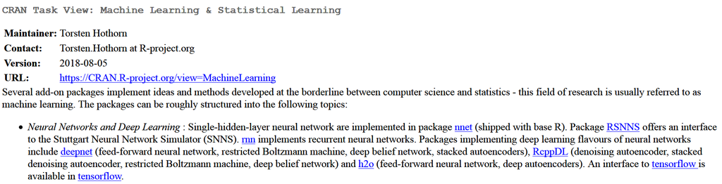

# Install all packages of a task view

```r
install.packages("ctv")
ctv::install.views("MachineLearning")
```

# Exercise: Find R-packages

Go to https://cran.r-project.org/ and search for packages that can be used:

1. to reduce overfitting
2. for regression trees
3. for gradient boosting
4. for neural networks
5. for clustering

# Preparation - packages

```r
library(dplyr)
```

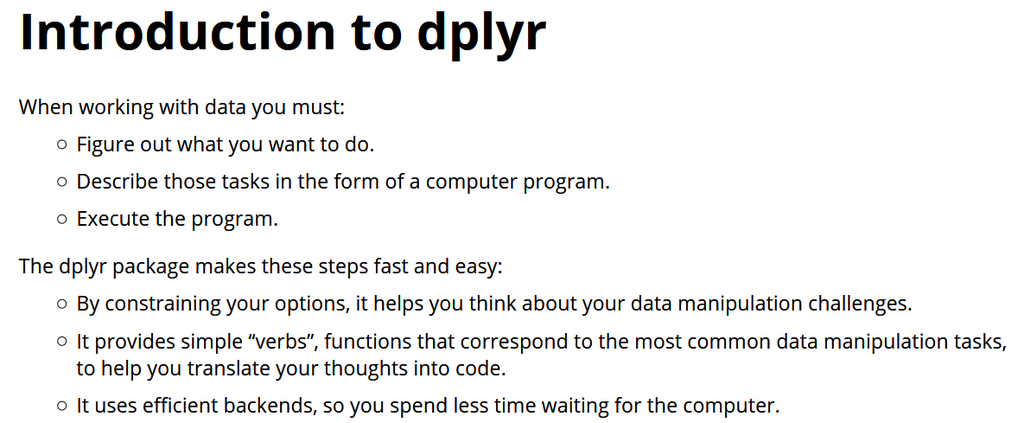

# The package `magrittr`

```r
library(magrittr)
```

# Import `.csv` data

### The `read.csv` command

- Use `read.csv2` for German data

```r
?read.csv
?read.csv2
```

### Using a path to import data

```r
path1<-"https://raw.githubusercontent.com/"
path2<- "thomaspernet/data_csv_r/master/data/"
dname <- "titanic_csv.csv"
titanic <- read.csv(paste0(path1,path2,dname))
```

### Save the dataset

```r
save(titanic,file="../data/titanic.RData")
```

# The titanic dataset

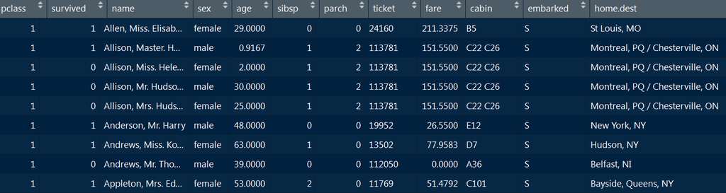

# The function `scan` to import data

- `scan` has an easy way to distinguish comments from data

```r
?scan
```

### Example dataset

```r
cat("TITLE extra line", "# a comment","2 3 5 7", "11 13 17",
    file = "../data/ex.data", sep = "\n")
```

### Import data and skip the first line

```r
pp<-scan("../data/ex.data",skip=1,quiet=TRUE)
```

```r
pp <- scan("../data/ex.data",comment.char="#", skip = 1,
           quiet = TRUE)
```

# The download the data from UCI.

```r
path1 <- "http://archive.ics.uci.edu/ml/"
path2 <- "machine-learning-databases/00243/"
dname <- 'yacht_hydrodynamics.data'
```

```r
url<- paste0(path1,path2,dname)
Yacht_Data <- readr::read_table(file = url)
```

# Built in datasets

- A sample dataset is often provided to demonstrate the functionality of a package.
- These records can be loaded using the `data` command.

```r
data(iris)
```

- There is also a [**RStudio Add-In**](https://github.com/bquast/datasets.load) that helps to find a built-in dataset.

```r
install.packages("datasets.load")
```

# Help page for built in datasets

```r
?kyphosis
```

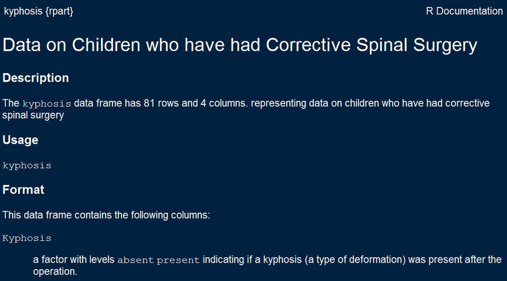

# Excursus [RStudio Addins](https://cran.r-project.org/web/packages/addinslist/README.html)

- In the upper right corner there is a button Addins

[figure not shown]

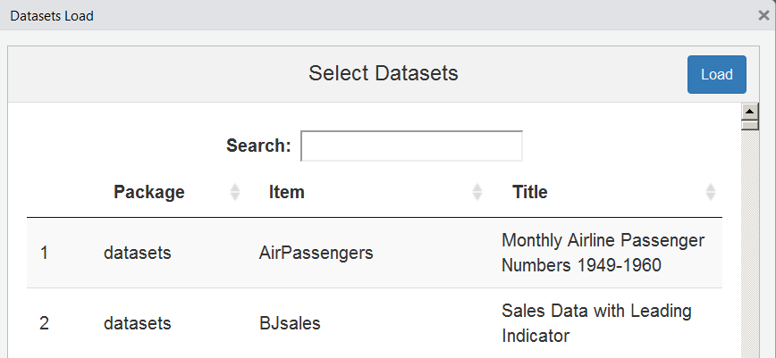

# How to get help

- I use **duckduckgo:**

```
R-project + "what I want to know"
```

- this works of course for all search engines!

[figure not shown]

# Exercise: load built-in data

### Load the the built-in dataset `swiss`

1. How many observations and variables are available?
2. What is the scale level of the variables?

### Interactive data table

3. Create an interactive data table

# The R-package `data.table`

### Get an overview

```r
data(airquality)
head(airquality)
```

```
##   Ozone Solar.R Wind Temp Month Day
## 1    41     190  7.4   67     5   1
## 2    36     118  8.0   72     5   2
## 3    12     149 12.6   74     5   3
## 4    18     313 11.5   62     5   4
## 5    NA      NA 14.3   56     5   5
## 6    28      NA 14.9   66     5   6
```

# Overview with `data.table`

```r
library(data.table)
(airq <- data.table(airquality))
```

```
##      Ozone Solar.R Wind Temp Month Day
##   1:    41     190  7.4   67     5   1
##   2:    36     118  8.0   72     5   2
##   3:    12     149 12.6   74     5   3
##   4:    18     313 11.5   62     5   4
##   5:    NA      NA 14.3   56     5   5
##  ---
## 149:    30     193  6.9   70     9  26
## 150:    NA     145 13.2   77     9  27
## 151:    14     191 14.3   75     9  28
## 152:    18     131  8.0   76     9  29
## 153:    20     223 11.5   68     9  30
```

# Column (and row) names of `airq`

```r
colnames(airq)
```

```
## [1] "Ozone"   "Solar.R" "Wind"    "Temp"    "Month"   "Day"
```

```r
rownames(airq)
```

```
##   [1] "1"   "2"   "3"   "4"   "5"   "6"   "7"   "8"   "9"   "10"  "11"  "12"
##  [13] "13"  "14"  "15"  "16"  "17"  "18"  "19"  "20"  "21"  "22"  "23"  "24"
##  [25] "25"  "26"  "27"  "28"  "29"  "30"  "31"  "32"  "33"  "34"  "35"  "36"
##  [37] "37"  "38"  "39"  "40"  "41"  "42"  "43"  "44"  "45"  "46"  "47"  "48"
##  [49] "49"  "50"  "51"  "52"  "53"  "54"  "55"  "56"  "57"  "58"  "59"  "60"
##  [61] "61"  "62"  "63"  "64"  "65"  "66"  "67"  "68"  "69"  "70"  "71"  "72"
##  [73] "73"  "74"  "75"  "76"  "77"  "78"  "79"  "80"  "81"  "82"  "83"  "84"
##  [85] "85"  "86"  "87"  "88"  "89"  "90"  "91"  "92"  "93"  "94"  "95"  "96"
##  [97] "97"  "98"  "99"  "100" "101" "102" "103" "104" "105" "106" "107" "108"
## [109] "109" "110" "111" "112" "113" "114" "115" "116" "117" "118" "119" "120"
## [121] "121" "122" "123" "124" "125" "126" "127" "128" "129" "130" "131" "132"
## [133] "133" "134" "135" "136" "137" "138" "139" "140" "141" "142" "143" "144"
## [145] "145" "146" "147" "148" "149" "150" "151" "152" "153"
```

# Command `mutate` - create or transform variables

```r
?dplyr::mutate
```

```r
airq %>%
  mutate(Temp / max(Temp, na.rm = TRUE))
```

```
##     Ozone Solar.R Wind Temp Month Day Temp/max(Temp, na.rm = TRUE)
## 1      41     190  7.4   67     5   1                    0.6907216
## 2      36     118  8.0   72     5   2                    0.7422680
## 3      12     149 12.6   74     5   3                    0.7628866
## 4      18     313 11.5   62     5   4                    0.6391753
## 5      NA      NA 14.3   56     5   5                    0.5773196
## 6      28      NA 14.9   66     5   6                    0.6804124
## 7      23     299  8.6   65     5   7                    0.6701031
## 8      19      99 13.8   59     5   8                    0.6082474
## 9       8      19 20.1   61     5   9                    0.6288660
## 10     NA     194  8.6   69     5  10                    0.7113402
## 11      7      NA  6.9   74     5  11                    0.7628866
## 12     16     256  9.7   69     5  12                    0.7113402
## 13     11     290  9.2   66     5  13                    0.6804124
## 14     14     274 10.9   68     5  14                    0.7010309
```

[output cut: 139 more lines]

# [Exercise](https://www.datacamp.com/community/tutorials/pipe-r-tutorial): random numbers

1. Draw 8 random numbers from the uniform distribution and save them in a vector `x`
2. Compute the logarithm of `x`, return suitably lagged and iterated differences,
3. compute the exponential function and round the result

[output not shown]

# [The pipe operator](https://www.datacamp.com/community/tutorials/pipe-r-tutorial)

```r
library(magrittr)

# Perform the same computations on `x` as above
x %>% log() %>%
    diff() %>%
    exp() %>%
    round(1)
```

```
## [1] 0.4 1.2 2.2 0.3 2.5 0.7 1.0
```

# How to deal with missing values

```r
?na.omit
```

```r
airq
```

```
##      Ozone Solar.R Wind Temp Month Day
##   1:    41     190  7.4   67     5   1
##   2:    36     118  8.0   72     5   2
##   3:    12     149 12.6   74     5   3
##   4:    18     313 11.5   62     5   4
##   5:    NA      NA 14.3   56     5   5
##  ---
## 149:    30     193  6.9   70     9  26
## 150:    NA     145 13.2   77     9  27
## 151:    14     191 14.3   75     9  28
## 152:    18     131  8.0   76     9  29
## 153:    20     223 11.5   68     9  30
```

# The command `na.omit`

```r
na.omit(airq)
```

```
##      Ozone Solar.R Wind Temp Month Day
##   1:    41     190  7.4   67     5   1
##   2:    36     118  8.0   72     5   2
##   3:    12     149 12.6   74     5   3
##   4:    18     313 11.5   62     5   4
##   5:    23     299  8.6   65     5   7
##  ---
## 107:    14      20 16.6   63     9  25
## 108:    30     193  6.9   70     9  26
## 109:    14     191 14.3   75     9  28
## 110:    18     131  8.0   76     9  29
## 111:    20     223 11.5   68     9  30
```

# Available loops in R

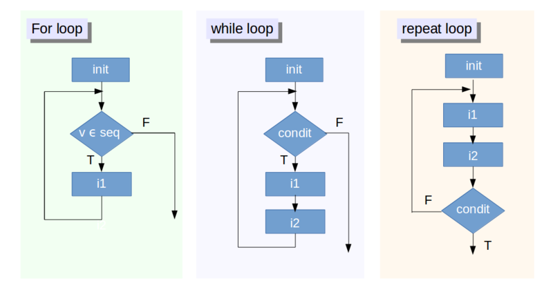

# Loops in R

- This loop calculates the square of the first 10 elements of vector u1

```r
u1 <- rnorm(30)
# Initialize `usq`
usq <- 0
for(i in 1:10) {
  # i-th element of `u1` squared into `i`-th position of `usq`
  usq[i] <- u1[i]*u1[i]
  print(usq[i])
}
```

```
## [1] 0.1944315
## [1] 0.7357985
## [1] 0.944911
## [1] 0.1481003
## [1] 0.1359454
## [1] 2.320677
## [1] 1.469417
## [1] 0.132293
## [1] 0.3588369
## [1] 5.24337
```

```r
print(i)
```

```
## [1] 10
```

# [Library `purrr`](https://r4ds.had.co.nz/iteration.html)

### `purrr` - Functional Programming Tools

- The pattern of looping over a vector, doing something to each element and saving the results is so common that the purrr package provides a family of functions to do it for you.

```r
library(purrr)
```

- `map()` makes a list.
- `map_lgl()` makes a logical vector.
- `map_int()` makes an integer vector.
- `map_dbl()` makes a double vector.
- `map_chr()` makes a character vector.

# Example `map_dbl`

```r
map_dbl(airq, mean)
```

```
##     Ozone   Solar.R      Wind      Temp     Month       Day
##        NA        NA  9.957516 77.882353  6.993464 15.803922
```

```r
map_dbl(airq, mean,na.rm=T)
```

```
##      Ozone    Solar.R       Wind       Temp      Month        Day
##  42.129310 185.931507   9.957516  77.882353   6.993464  15.803922
```

# [Clean the titanic data set](https://www.guru99.com/r-decision-trees.html)

```r
clean_titanic <- titanic %>%
  mutate(pclass=factor(pclass,levels = c(1, 2, 3),
                       labels=c('Upper','Middle','Lower')),
    survived = factor(survived,levels = c(0, 1),
                      labels=c('No', 'Yes'))) %>%
na.omit()
```

### `mutate(pclass = factor(...`:

- Add label to the variable pclass.
- 1 becomes Upper, 2 becomes MIddle and 3 becomes lower

# Get an overview of the data

```r
glimpse(clean_titanic)
```

```
## Observations: 1,045
## Variables: 13
## $ X         <int> 1, 2, 3, 4, 5, 6, 7, 8, 9, 10, 11, 12, 13, 14, 15, 17, 18...
## $ pclass    <fct> Upper, Upper, Upper, Upper, Upper, Upper, Upper, Upper, U...
## $ survived  <fct> Yes, Yes, No, No, No, Yes, Yes, No, Yes, No, No, Yes, Yes...
## $ name      <fct> "Allen, Miss. Elisabeth Walton", "Allison, Master. Hudson...
## $ sex       <fct> female, male, female, male, female, male, female, male, f...
## $ age       <dbl> 29.0000, 0.9167, 2.0000, 30.0000, 25.0000, 48.0000, 63.00...
## $ sibsp     <int> 0, 1, 1, 1, 1, 0, 1, 0, 2, 0, 1, 1, 0, 0, 0, 0, 0, 0, 0, ...
## $ parch     <int> 0, 2, 2, 2, 2, 0, 0, 0, 0, 0, 0, 0, 0, 0, 0, 1, 1, 0, 0, ...
## $ ticket    <fct> 24160, 113781, 113781, 113781, 113781, 19952, 13502, 1120...
## $ fare      <dbl> 211.3375, 151.5500, 151.5500, 151.5500, 151.5500, 26.5500...
## $ cabin     <fct> B5, C22 C26, C22 C26, C22 C26, C22 C26, E12, D7, A36, C10...
## $ embarked  <fct> S, S, S, S, S, S, S, S, S, C, C, C, C, S, S, C, C, C, C, ...
## $ home.dest <fct> "St Louis, MO", "Montreal, PQ / Chesterville, ON", "Montr...
```

# [With `gather` from wide to long format](http://stackoverflow.com/questions/1181060)

```r
library(dplyr)
library(tidyr)
stocks <- tibble(
  time = as.Date('2009-01-01') + 0:9,
  X = rnorm(10, 0, 1),
  Y = rnorm(10, 0, 2),
  Z = rnorm(10, 0, 4)
)

gather(stocks, "stock", "price", -time)
```

```
## # A tibble: 30 x 3
##    time       stock  price
##    <date>     <chr>  <dbl>
##  1 2009-01-01 X     -0.789
##  2 2009-01-02 X     -0.887
##  3 2009-01-03 X     -0.352
##  4 2009-01-04 X     -0.996
##  5 2009-01-05 X      1.94
##  6 2009-01-06 X     -0.557
##  7 2009-01-07 X     -0.523
##  8 2009-01-08 X      0.355
##  9 2009-01-09 X      0.636
## 10 2009-01-10 X      0.561
## # ... with 20 more rows
```

# Sequences

- Later we will create hyperparameter grids.
- To do so, we will need sequences

```r
# the easiest sequence
1:4
```

```
## [1] 1 2 3 4
```

```r
# the other way
4:1
```

```
## [1] 4 3 2 1
```

```r
# the command sequence
seq(start=1,to = 10,by = 2)
```

```
## [1] 1 3 5 7 9
```

```r
# we will need the following for loops
seq_along(14:21)
```

```
## [1] 1 2 3 4 5 6 7 8
```

# The command `expand.grid`

```r
expand.grid(letters[1:4],5:3,LETTERS[1:2])
```

```
##    Var1 Var2 Var3
## 1     a    5    A
## 2     b    5    A
## 3     c    5    A
## 4     d    5    A
## 5     a    4    A
## 6     b    4    A
## 7     c    4    A
## 8     d    4    A
## 9     a    3    A
## 10    b    3    A
## 11    c    3    A
## 12    d    3    A
## 13    a    5    B
## 14    b    5    B
## 15    c    5    B
## 16    d    5    B
## 17    a    4    B
## 18    b    4    B
## 19    c    4    B
## 20    d    4    B
## 21    a    3    B
## 22    b    3    B
## 23    c    3    B
## 24    d    3    B
```

# [Example Data - Housing Values in Suburbs of Boston](https://datascienceplus.com/fitting-neural-network-in-r/)

```r
library(MASS)
bdat <- Boston
```

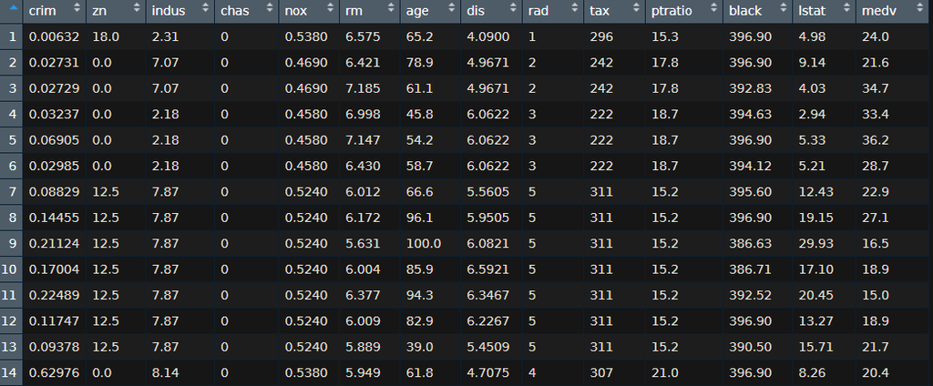

# Normalize your data

### Compute maximum and minimum per column

```r
maxs <- apply(bdat, 2, max)
mins <- apply(bdat, 2, min)
```

### `scale` - Scaling and Centering of Matrix-like Objects

```r
scaled <- as.data.frame(scale(bdat, center = mins,
                              scale = maxs - mins))
```

# The scaled data

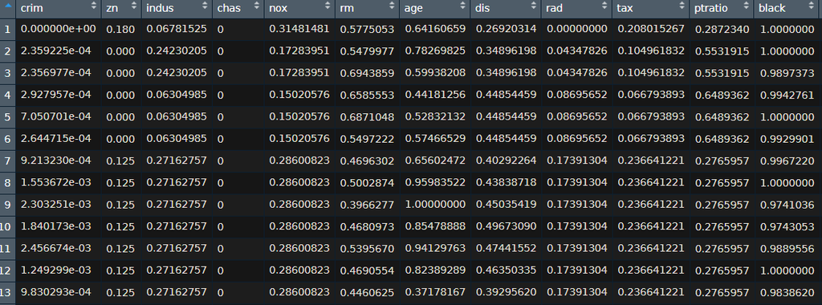

# The command `sample`

- We can use this command to draw a sample.
- We need the command later to split our dataset into a test and a training dataset.

```r
sample(1:10,3,replace=T)
```

```
## [1]  1 10  9
```

```r
sample(1:10,3,replace=T)
```

```
## [1] 8 6 8
```

### Create test and training datasets

```r
ntest <- round(nrow(bdat)*.2)
ind <- sample(1:nrow(bdat),ntest)
bdat_test <- bdat[ind,]
bdat_train <- bdat[-ind,]
```

# Alternative to split a dataset

- `Y` - Vector of data labels. If there are only a few labels (as is expected) than relative ratio of data in both subsets will be the same.
- `SplitRatio` - Splitting ratio

```r
split <- caTools::sample.split(Y = bdat$lstat,SplitRatio = .8)
Train <- bdat[split,]
Test <- bdat[!split,]
nrow(Train);nrow(Test)
```

```
## [1] 404
```

```
## [1] 102
```

# [Dealing with missingness](https://bradleyboehmke.github.io/HOML/engineering.html#dealing-with-missingness)

- It is important to understand the distribution of missing values

```r
sum(is.na(AmesHousing::ames_raw))
```

```
## [1] 13997
```

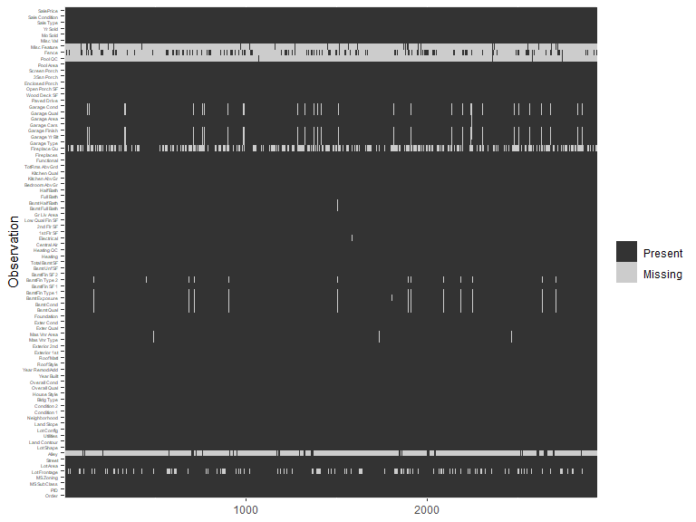

```r
library(magrittr)
library(tidyverse)

AmesHousing::ames_raw %>%
  is.na() %>%
  reshape2::melt() %>%
  ggplot(aes(Var2, Var1, fill=value)) +
    geom_raster() +
    coord_flip() +
    scale_y_continuous(NULL, expand = c(0, 0)) +
    scale_fill_grey(name = "",
                    labels = c("Present",
                               "Missing")) +
    xlab("Observation") +
    theme(axis.text.y  = element_text(size = 4))
```

# Set a seed

- `set.seed` is the recommended way to specify seeds.
- If we set a seed, we get the same result for random events.
- This function is mainly required for simulations.

```r
set.seed(234)
sample(1:10,3,replace=T)
```

```
## [1] 1 2 2
```

```r
set.seed(234)
sample(1:10,3,replace=T)
```

```
## [1] 1 2 2
```

# [Time measurement](https://www.r-bloggers.com/5-ways-to-measure-running-time-of-r-code/)

```r
start_time <- Sys.time()
ab <- runif(10000000)
end_time <- Sys.time()

end_time - start_time
```

```
## Time difference of 0.4737399 secs
```

# How many cores are available

```r
library(doParallel)
detectCores()
```

```
## [1] 4
```

# Make cluster

```r
cl <- makeCluster(detectCores())
registerDoParallel(cl)
```

```r
start_time <- Sys.time()
ab <- runif(10000000)
end_time <- Sys.time()

end_time - start_time
```

```
## Time difference of 0.4183249 secs
```

```r
stopCluster(cl)
```

```r
?parallel::makeCluster
```

# Resources

- [**Course materials for the Data Science Specialization**](https://github.com/DataScienceSpecialization/courses)
- Data wrangling - [**`dplyr` vignette**](https://cran.r-project.org/web/packages/dplyr/vignettes/dplyr.html) -
- The usage of pipes - [**`magrittr` vignette**](https://cran.r-project.org/web/packages/magrittr/vignettes/magrittr.html)
- Gareth James et al (2013) [**An Introduction to Statistical Learning**](https://www-bcf.usc.edu/~gareth/ISL/ISLR%20First%20Printing.pdf)